# Elsevier 2022 SDG mapping

# General to all SDGs

## Introduction

The United Nations Sustainable Development Goals (SDGs) challenge the global community to build a world where no one is left behind.

Since 2018, Elsevier has generated SDG search queries to help researchers and institutions track and demonstrate progress toward the SDG targets. In the past 3 years, these queries, along with the university’s own data and evidence supporting progress and contributions to the particular SDG outside of research-based metrics, are used for the THE Impact Rankings.

## Method

For 2022, this SDG uses the exact same search query and ML algorithm as the Elsevier 2021 SDG mapping. [Full details of the 2021 methodology are available on Digital Commons Data.](https://elsevier.digitalcommonsdata.com/datasets/9sxdykm8s4/4)

# [SDG 8 - Promote sustained, inclusive and sustainable economic growth, full and productive employment and decent work for all](https://sdgs.un.org/goals/goal8)

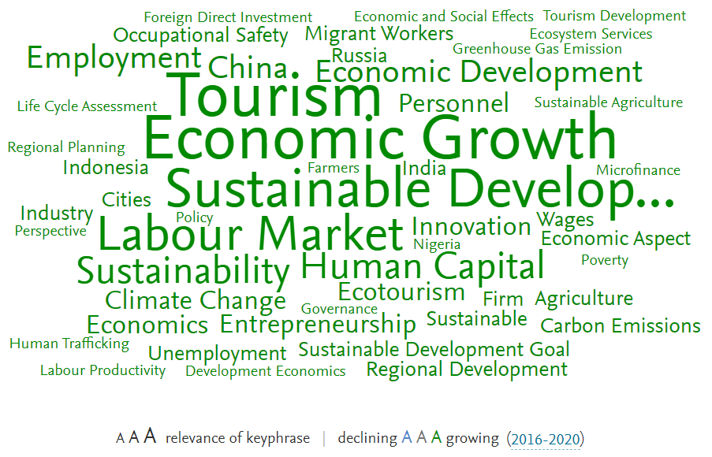

Explore this wordcloud plus the most active contributors on the [SciVal SDG site](https://scival.com/sdg)

## Query

Below is the full search query used for this SDG. We’ve broken it down by each query component. Use the + and – to concatenate the different bracket levels.

(

(

TITLE-ABS

(

"labor law"

)

OR AUTHKEY

(

"labor law"

)

OR TITLE-ABS

(

"decent work"

)

OR AUTHKEY

(

"decent work"

)

OR TITLE-ABS

(

"wage differential"

)

OR AUTHKEY

(

"wage differential"

)

OR TITLE-ABS

(

"school leaving"

)

OR AUTHKEY

(

"school leaving"

)

OR TITLE-ABS

(

"wage differential"

)

OR AUTHKEY

(

"wage differential"

)

OR TITLE-ABS

(

"wage gap"

)

OR AUTHKEY

(

"wage gap"

)

OR TITLE-ABS

(

"employment insecurity"

)

OR AUTHKEY

(

"employment insecurity"

)

OR TITLE-ABS

(

"school to work"

)

OR AUTHKEY

(

"school to work"

)

OR TITLE-ABS

(

"employment protection"

)

OR AUTHKEY

(

"employment protection"

)

OR TITLE-ABS

(

"labour market"

)

OR AUTHKEY

(

"labour market"

)

OR TITLE-ABS

(

"informal employment"

)

OR AUTHKEY

(

"informal employment"

)

OR TITLE-ABS

(

"decent employment"

)

OR AUTHKEY

(

"decent employment"

)

OR TITLE-ABS

(

"Flexible working hours"

)

OR AUTHKEY

(

"Flexible working hours"

)

OR TITLE-ABS

(

"pay equity"

)

OR AUTHKEY

(

"pay equity"

)

OR TITLE-ABS

(

"youth employment"

)

OR AUTHKEY

(

"youth employment"

)

OR TITLE-ABS

(

"women''s employment"

)

OR AUTHKEY

(

"women''s employment"

)

OR

(

TITLE-ABS

(

"*economic* polic*"

)

AND TITLE-ABS

(

"unemployment"

)

)

OR

(

AUTHKEY

(

"*economic* polic*"

)

AND AUTHKEY

(

"unemployment"

)

)

OR TITLE-ABS

(

"wage* inequalit*"

)

OR AUTHKEY

(

"wage* inequalit*"

)

OR TITLE-ABS

(

"returns to college"

)

OR AUTHKEY

(

"returns to college"

)

OR TITLE-ABS

(

"pay gap"

)

OR AUTHKEY

(

"pay gap"

)

OR TITLE-ABS

(

"labour relations"

)

OR AUTHKEY

(

"labour relations"

)

OR

(

TITLE-ABS

(

"time-related underemployment"

)

OR TITLE-ABS

(

"timerelated underemployment"

)

)

OR

(

AUTHKEY

(

"time-related underemployment"

)

OR AUTHKEY

(

"timerelated underemployment"

)

)

OR TITLE-ABS

(

"gender division of labour"

)

OR AUTHKEY

(

"gender division of labour"

)

OR

(

TITLE-ABS

(

"quality of employment"

)

AND TITLE-ABS

(

"economic*"

)

)

OR

(

AUTHKEY

(

"quality of employment"

)

AND AUTHKEY

(

"economic*"

)

)

OR TITLE-ABS

(

"earnings gap"

)

OR AUTHKEY

(

"earnings gap"

)

OR

(

(

TITLE-ABS("self-employment") AND TITLE-ABS("economic*")

)

OR

(

TITLE-ABS("selfemployment") AND TITLE-ABS("economic*")

)

)

OR

(

(

AUTHKEY("self-employment") AND AUTHKEY("economic*")

)

OR

(

AUTHKEY("selfemployment") AND AUTHKEY("economic*")

)

)

OR TITLE-ABS

(

"equal pay guide"

)

OR AUTHKEY

(

"equal pay guide"

)

OR TITLE-ABS

(

"employment quality"

)

OR AUTHKEY

(

"employment quality"

)

OR TITLE-ABS

(

"women''s labor supply"

)

OR AUTHKEY

(

"women''s labor supply"

)

OR TITLE-ABS

(

"returns to education"

)

OR AUTHKEY

(

"returns to education"

)

OR TITLE-ABS

(

"women''s labour force"

)

OR AUTHKEY

(

"women''s labour force"

)

OR TITLE-ABS

(

"gender earnings gap"

)

OR AUTHKEY

(

"gender earnings gap"

)

OR

(

TITLE-ABS

(

"labour supply"

)

AND TITLE-ABS

(

"economic*"

)

)

OR

(

AUTHKEY

(

"labour supply"

)

AND AUTHKEY

(

"economic*"

)

)

OR TITLE-ABS

(

"employment creation"

)

OR AUTHKEY

(

"employment creation"

)

OR TITLE-ABS

(

"labour law"

)

OR AUTHKEY

(

"labour law"

)

OR TITLE-ABS

(

"parental employment"

)

OR AUTHKEY

(

"parental employment"

)

OR TITLE-ABS

(

"female labour participation"

)

OR AUTHKEY

(

"female labour participation"

)

OR

(

TITLE-ABS

(

"overeducation"

)

AND TITLE-ABS

(

"unemployment"

)

)

OR

(

AUTHKEY

(

"overeducation"

)

AND AUTHKEY

(

"unemployment"

)

)

OR

(

TITLE-ABS

(

"non-standard employment"

)

OR TITLE-ABS

(

"nonstandard employment"

)

)

OR

(

AUTHKEY

(

"non-standard employment"

)

OR AUTHKEY

(

"nonstandard employment"

)

)

OR TITLE-ABS

(

"pay discrimination"

)

OR AUTHKEY

(

"pay discrimination"

)

OR TITLE-ABS

(

"pay gaps"

)

OR AUTHKEY

(

"pay gaps"

)

OR TITLE-ABS

(

"job stability"

)

OR AUTHKEY

(

"job stability"

)

OR TITLE-ABS

(

"occupational segregation"

)

OR AUTHKEY

(

"occupational segregation"

)

OR TITLE-ABS

(

"full and productive employment"

)

OR AUTHKEY

(

"full and productive employment"

)

OR TITLE-ABS

(

"female labor participation"

)

OR AUTHKEY

(

"female labor participation"

)

OR TITLE-ABS

(

"Maternal employment"

)

OR AUTHKEY

(

"Maternal employment"

)

OR TITLE-ABS

(

"equal pay for equal work"

)

OR AUTHKEY

(

"equal pay for equal work"

)

OR TITLE-ABS

(

"wage premia"

)

OR AUTHKEY

(

"wage premia"

)

OR TITLE-ABS

(

"wage differences"

)

OR AUTHKEY

(

"wage differences"

)

OR

(

TITLE-ABS

(

"labour standards"

)

AND TITLE-ABS

(

"economic*"

)

)

OR

(

AUTHKEY

(

"labour standards"

)

AND AUTHKEY

(

"economic*"

)

)

OR TITLE-ABS

(

"employment security"

)

OR AUTHKEY

(

"employment security"

)

OR TITLE-ABS

(

"gender division of labor"

)

OR AUTHKEY

(

"gender division of labor"

)

OR

(

TITLE-ABS

(

"quality employment"

)

AND TITLE-ABS

(

"economic*"

)

)

OR

(

AUTHKEY

(

"quality employment"

)

AND AUTHKEY

(

"economic*"

)

)

OR

(

TITLE-ABS

(

"migrant worker"

)

AND TITLE-ABS

(

"economic*"

)

)

OR

(

AUTHKEY

(

"migrant worker"

)

AND AUTHKEY

(

"economic*"

)

)

OR TITLE-ABS

(

"employment equity"

)

OR AUTHKEY

(

"employment equity"

)

OR

(

(

TITLE-ABS("self-employment") AND TITLE-ABS("jobs")

)

OR

(

TITLE-ABS("selfemployment") AND TITLE-ABS("jobs")

)

)

OR

(

(

AUTHKEY("self-employment") AND AUTHKEY("jobs")

)

OR

(

AUTHKEY("selfemployment") AND AUTHKEY("jobs")

)

)

OR TITLE-ABS

(

"labour legislation"

)

OR AUTHKEY

(

"labour legislation"

)

OR TITLE-ABS

(

"labour and employment relations"

)

OR AUTHKEY

(

"labour and employment relations"

)

OR TITLE-ABS

(

"flexicurity"

)

OR AUTHKEY

(

"flexicurity"

)

OR TITLE-ABS

(

"employment equity act"

)

OR AUTHKEY

(

"employment equity act"

)

OR TITLE-ABS

(

"gender pay equity"

)

OR AUTHKEY

(

"gender pay equity"

)

OR TITLE-ABS

(

"female labor force participation"

)

OR AUTHKEY

(

"female labor force participation"

)

OR TITLE-ABS

(

"labor market"

)

OR AUTHKEY

(

"labor market"

)

OR

(

TITLE-ABS

(

"work-force participation"

)

OR TITLE-ABS

(

"workforce participation"

)

)

OR

(

AUTHKEY

(

"work-force participation"

)

OR AUTHKEY

(

"workforce participation"

)

)

OR TITLE-ABS

(

"vulnerable employment"

)

OR AUTHKEY

(

"vulnerable employment"

)

OR TITLE-ABS

(

"employment and poverty"

)

OR AUTHKEY

(

"employment and poverty"

)

OR TITLE-ABS

(

"pay discrimination"

)

OR AUTHKEY

(

"pay discrimination"

)

OR

(

(

TITLE-ABS("self-employment") AND TITLE-ABS("work")

)

OR

(

TITLE-ABS("selfemployment") AND TITLE-ABS("work")

)

)

OR

(

(

AUTHKEY("self-employment") AND AUTHKEY("work")

)

OR

(

AUTHKEY("selfemployment") AND AUTHKEY("work")

)

)

OR TITLE-ABS

(

"equal pay for work"

)

OR AUTHKEY

(

"equal pay for work"

)

OR TITLE-ABS

(

"wage differentials"

)

OR AUTHKEY

(

"wage differentials"

)

OR TITLE-ABS

(

"women* entrepreneur*"

)

OR AUTHKEY

(

"women* entrepreneur*"

)

OR TITLE-ABS

(

"job search"

)

OR AUTHKEY

(

"job search"

)

OR TITLE-ABS

(

"female labour force participation"

)

OR AUTHKEY

(

"female labour force participation"

)

OR TITLE-ABS

(

"green employment"

)

OR AUTHKEY

(

"green employment"

)

OR TITLE-ABS

(

"labor relations"

)

OR AUTHKEY

(

"labor relations"

)

OR TITLE-ABS

(

"nonstandard* work* schedule*"

)

OR AUTHKEY

(

"nonstandard* work* schedule*"

)

OR

(

TITLE-ABS

(

"employment* condition*"

)

AND TITLE-ABS

(

"economic*"

)

)

OR

(

AUTHKEY

(

"employment* condition*"

)

AND AUTHKEY

(

"economic*"

)

)

OR TITLE-ABS

(

"productive employment"

)

OR AUTHKEY

(

"productive employment"

)

OR TITLE-ABS

(

"young workers"

)

OR AUTHKEY

(

"young workers"

)

OR TITLE-ABS

(

"equal remuneration convention"

)

OR AUTHKEY

(

"equal remuneration convention"

)

OR TITLE-ABS

(

"wage premium"

)

OR AUTHKEY

(

"wage premium"

)

OR TITLE-ABS

(

"wage discrimination"

)

OR AUTHKEY

(

"wage discrimination"

)

OR

(

TITLE-ABS

(

"employment"

)

AND TITLE-ABS

(

"*economic* polic*"

)

)

OR

(

AUTHKEY

(

"employment"

)

AND AUTHKEY

(

"*economic* polic*"

)

)

OR TITLE-ABS

(

"wage premiums"

)

OR AUTHKEY

(

"wage premiums"

)

OR TITLE-ABS

(

"women''s labor force"

)

OR AUTHKEY

(

"women''s labor force"

)

OR TITLE-ABS

(

"international labour standards"

)

OR AUTHKEY

(

"international labour standards"

)

OR TITLE-ABS

(

"female employment"

)

OR AUTHKEY

(

"female employment"

)

OR TITLE-ABS

(

"labor and employment law"

)

OR AUTHKEY

(

"labor and employment law"

)

OR

(

TITLE-ABS

(

"labor supply"

)

AND TITLE-ABS

(

"economic*"

)

)

OR

(

AUTHKEY

(

"labor supply"

)

AND AUTHKEY

(

"economic*"

)

)

OR TITLE-ABS

(

"youth employability"

)

OR AUTHKEY

(

"youth employability"

)

OR TITLE-ABS

(

"wage employment"

)

OR AUTHKEY

(

"wage employment"

)

OR TITLE-ABS

(

"youth labour markets"

)

OR AUTHKEY

(

"youth labour markets"

)

OR

(

TITLE-ABS

(

"black women"

)

AND TITLE-ABS

(

"wage*"

)

)

OR

(

AUTHKEY

(

"black women"

)

AND AUTHKEY

(

"wage*"

)

)

OR TITLE-ABS

(

"equal employment"

)

OR AUTHKEY

(

"equal employment"

)

OR

(

TITLE-ABS

(

"women workers"

)

AND TITLE-ABS

(

"ILO"

)

)

OR

(

AUTHKEY

(

"women workers"

)

AND AUTHKEY

(

"ILO"

)

)

OR TITLE-ABS

(

"earnings inequality"

)

OR AUTHKEY

(

"earnings inequality"

)

OR

(

TITLE-ABS

(

"wage share"

)

AND TITLE-ABS

(

"economic*"

)

)

OR

(

AUTHKEY

(

"wage share"

)

AND AUTHKEY

(

"economic*"

)

)

OR TITLE-ABS

(

"racial wage"

)

OR AUTHKEY

(

"racial wage"

)

OR TITLE-ABS

(

"labor regulations"

)

OR AUTHKEY

(

"labor regulations"

)

OR TITLE-ABS

(

"job insecurity"

)

OR AUTHKEY

(

"job insecurity"

)

OR

(

TITLE-ABS

(

"ilo"

)

AND TITLE-ABS

(

"convention 169"

)

)

OR

(

AUTHKEY

(

"ilo"

)

AND AUTHKEY

(

"convention 169"

)

)

OR TITLE-ABS

(

"earnings inequality"

)

OR AUTHKEY

(

"earnings inequality"

)

OR TITLE-ABS

(

"Equal pay"

)

OR AUTHKEY

(

"Equal pay"

)

OR TITLE-ABS

(

"unemployed youth"

)

OR AUTHKEY

(

"unemployed youth"

)

OR TITLE-ABS

(

"hiring discrimination:"

)

OR AUTHKEY

(

"hiring discrimination:"

)

OR TITLE-ABS

(

"wage gaps"

)

OR AUTHKEY

(

"wage gaps"

)

OR

(

TITLE-ABS

(

"affirmative* action*"

)

AND TITLE-ABS

(

"job*"

)

)

OR

(

AUTHKEY

(

"affirmative* action*"

)

AND AUTHKEY

(

"job*"

)

)

OR TITLE-ABS

(

"living wage"

)

OR AUTHKEY

(

"living wage"

)

OR TITLE-ABS

(

"wage inequality"

)

OR AUTHKEY

(

"wage inequality"

)

OR

(

TITLE-ABS

(

"employment"

)

AND TITLE-ABS

(

"Affirmative action"

)

)

OR

(

AUTHKEY

(

"employment"

)

AND AUTHKEY

(

"Affirmative action"

)

)

OR TITLE-ABS

(

"labor markets"

)

OR AUTHKEY

(

"labor markets"

)

OR TITLE-ABS

(

"minimum wage"

)

OR AUTHKEY

(

"minimum wage"

)

OR

(

TITLE-ABS

(

"economic growth"

)

AND TITLE-ABS

(

"gini"

)

)

OR

(

AUTHKEY

(

"economic growth"

)

AND AUTHKEY

(

"gini"

)

)

OR TITLE-ABS

(

"low* wage* job*"

)

OR AUTHKEY

(

"low* wage* job*"

)

OR TITLE-ABS

(

"returns to schooling"

)

OR AUTHKEY

(

"returns to schooling"

)

OR

(

TITLE-ABS

(

" self-employment"

)

OR TITLE-ABS

(

" selfemployment"

)

)

OR

(

AUTHKEY

(

" self-employment"

)

OR AUTHKEY

(

" selfemployment"

)

)

OR TITLE-ABS

(

"wage disparity"

)

OR AUTHKEY

(

"wage disparity"

)

OR

(

TITLE-ABS

(

"coal workers"

)

AND TITLE-ABS

(

"ilo"

)

)

OR

(

AUTHKEY

(

"coal workers"

)

AND AUTHKEY

(

"ilo"

)

)

OR

(

TITLE-ABS

(

"affirmative* action*"

)

AND TITLE-ABS

(

"salar*"

)

)

OR

(

AUTHKEY

(

"affirmative* action*"

)

AND AUTHKEY

(

"salar*"

)

)

OR TITLE-ABS

(

"worker displacement"

)

OR AUTHKEY

(

"worker displacement"

)

OR TITLE-ABS

(

"wage growth"

)

OR AUTHKEY

(

"wage growth"

)

OR TITLE-ABS

(

"youth labor"

)

OR AUTHKEY

(

"youth labor"

)

OR TITLE-ABS

(

"wage disparities"

)

OR AUTHKEY

(

"wage disparities"

)

OR TITLE-ABS

(

"job displacement"

)

OR AUTHKEY

(

"job displacement"

)

OR

(

(

TITLE-ABS(" self-employed") AND TITLE-ABS("economic*")

)

OR

(

TITLE-ABS(" selfemployed") AND TITLE-ABS("economic*")

)

)

OR

(

(

AUTHKEY(" self-employed") AND AUTHKEY("economic*")

)

OR

(

AUTHKEY(" selfemployed") AND AUTHKEY("economic*")

)

)

OR TITLE-ABS

(

"wage disparities"

)

OR AUTHKEY

(

"wage disparities"

)

OR TITLE-ABS

(

"minimum wages"

)

OR AUTHKEY

(

"minimum wages"

)

OR TITLE-ABS

(

"youth unemployment"

)

OR AUTHKEY

(

"youth unemployment"

)

OR TITLE-ABS

(

"better work programme"

)

OR AUTHKEY

(

"better work programme"

)

OR TITLE-ABS

(

"ilo standards"

)

OR AUTHKEY

(

"ilo standards"

)

OR

(

TITLE-ABS

(

"wage*"

)

AND TITLE-ABS

(

"affirmative action"

)

)

OR

(

AUTHKEY

(

"wage*"

)

AND AUTHKEY

(

"affirmative action"

)

)

OR TITLE-ABS

(

"unemployed young people"

)

OR AUTHKEY

(

"unemployed young people"

)

OR

(

TITLE-ABS

(

"GDP growth"

)

AND TITLE-ABS

(

"gini"

)

)

OR

(

AUTHKEY

(

"GDP growth"

)

AND AUTHKEY

(

"gini"

)

)

OR

(

TITLE-ABS

(

"self-employed women"

)

OR TITLE-ABS

(

"selfemployed women"

)

)

OR

(

AUTHKEY

(

"self-employed women"

)

OR AUTHKEY

(

"selfemployed women"

)

)

OR TITLE-ABS

(

"wage bargaining"

)

OR AUTHKEY

(

"wage bargaining"

)

OR

(

TITLE-ABS

(

"work-related burden"

)

OR TITLE-ABS

(

"workrelated burden"

)

)

OR

(

AUTHKEY

(

"work-related burden"

)

OR AUTHKEY

(

"workrelated burden"

)

)

OR

(

TITLE-ABS

(

"workplace"

)

AND TITLE-ABS

(

"Affirmative action"

)

)

OR

(

AUTHKEY

(

"workplace"

)

AND AUTHKEY

(

"Affirmative action"

)

)

OR TITLE-ABS

(

"labour laws"

)

OR AUTHKEY

(

"labour laws"

)

OR TITLE-ABS

(

"active labour market policies"

)

OR AUTHKEY

(

"active labour market policies"

)

OR TITLE-ABS

(

"earnings discrimination"

)

OR AUTHKEY

(

"earnings discrimination"

)

OR TITLE-ABS

(

"young unemployed"

)

OR AUTHKEY

(

"young unemployed"

)

OR TITLE-ABS

(

"hiring discrimination"

)

OR AUTHKEY

(

"hiring discrimination"

)

OR TITLE-ABS

(

"labour standards"

)

OR AUTHKEY

(

"labour standards"

)

OR TITLE-ABS

(

"human capital"

)

OR AUTHKEY

(

"human capital"

)

OR TITLE-ABS

(

"labour regulations"

)

OR AUTHKEY

(

"labour regulations"

)

OR

(

TITLE-ABS

(

"hiring"

)

AND TITLE-ABS

(

"Affirmative action"

)

)

OR

(

AUTHKEY

(

"hiring"

)

AND AUTHKEY

(

"Affirmative action"

)

)

OR TITLE-ABS

(

"return to schooling"

)

OR AUTHKEY

(

"return to schooling"

)

OR

(

TITLE-ABS

(

"same jobs"

)

AND TITLE-ABS

(

"gender"

)

)

OR

(

AUTHKEY

(

"same jobs"

)

AND AUTHKEY

(

"gender"

)

)

OR

(

TITLE-ABS

(

"ilo convention"

)

AND TITLE-ABS

(

"169"

)

)

OR

(

AUTHKEY

(

"ilo convention"

)

AND AUTHKEY

(

"169"

)

)

)

)

OR

(

(

TITLE-ABS

(

"trade facilitation reform"

)

OR AUTHKEY

(

"trade facilitation reform"

)

OR TITLE-ABS

(

"aid versus trade"

)

OR AUTHKEY

(

"aid versus trade"

)

OR TITLE-ABS

(

"Enhanced Integrated Framework"

)

OR AUTHKEY

(

"Enhanced Integrated Framework"

)

OR TITLE-ABS

(

"Trade facilitation"

)

OR AUTHKEY

(

"Trade facilitation"

)

OR

(

TITLE-ABS

(

"exports"

)

AND TITLE-ABS

(

"technical assistance"

)

)

OR

(

AUTHKEY

(

"exports"

)

AND AUTHKEY

(

"technical assistance"

)

)

OR TITLE-ABS

(

"Technical assistance for exports"

)

OR AUTHKEY

(

"Technical assistance for exports"

)

OR TITLE-ABS

(

"trade sustainability"

)

OR AUTHKEY

(

"trade sustainability"

)

OR TITLE-ABS

(

"Trade Facilitation Agreement"

)

OR AUTHKEY

(

"Trade Facilitation Agreement"

)

OR TITLE-ABS

(

"trade related assistance"

)

OR AUTHKEY

(

"trade related assistance"

)

OR TITLE-ABS

(

"trade facilitation index"

)

OR AUTHKEY

(

"trade facilitation index"

)

OR

(

TITLE-ABS

(

"Trade"

)

AND TITLE-ABS

(

"technical cooperation"

)

)

OR

(

AUTHKEY

(

"Trade"

)

AND AUTHKEY

(

"technical cooperation"

)

)

OR

(

TITLE-ABS

(

"trade"

)

AND TITLE-ABS

(

"ethical consumption"

)

)

OR

(

AUTHKEY

(

"trade"

)

AND AUTHKEY

(

"ethical consumption"

)

)

OR TITLE-ABS

(

"aid and trade"

)

OR AUTHKEY

(

"aid and trade"

)

OR

(

TITLE-ABS

(

"foreign aid"

)

AND TITLE-ABS

(

"international trade"

)

)

OR

(

AUTHKEY

(

"foreign aid"

)

AND AUTHKEY

(

"international trade"

)

)

OR

(

TITLE-ABS

(

"foreign aid"

)

AND TITLE-ABS

(

"exports diversification"

)

)

OR

(

AUTHKEY

(

"foreign aid"

)

AND AUTHKEY

(

"exports diversification"

)

)

OR

(

TITLE-ABS

(

"foreign aid"

)

AND TITLE-ABS

(

"trade openness"

)

)

OR

(

AUTHKEY

(

"foreign aid"

)

AND AUTHKEY

(

"trade openness"

)

)

OR

(

TITLE-ABS

(

"foreign aid"

)

AND TITLE-ABS

(

"model of trade"

)

)

OR

(

AUTHKEY

(

"foreign aid"

)

AND AUTHKEY

(

"model of trade"

)

)

OR

(

TITLE-ABS

(

"foreign aid"

)

AND TITLE-ABS

(

"trade facilitation"

)

)

OR

(

AUTHKEY

(

"foreign aid"

)

AND AUTHKEY

(

"trade facilitation"

)

)

OR

(

TITLE-ABS

(

"foreign aid"

)

AND TITLE-ABS

(

"imports"

)

)

OR

(

AUTHKEY

(

"foreign aid"

)

AND AUTHKEY

(

"imports"

)

)

OR

(

TITLE-ABS

(

"foreign aid"

)

AND TITLE-ABS

(

"free trade"

)

)

OR

(

AUTHKEY

(

"foreign aid"

)

AND AUTHKEY

(

"free trade"

)

)

OR

(

TITLE-ABS

(

"foreign aid"

)

AND TITLE-ABS

(

"exports"

)

)

OR

(

AUTHKEY

(

"foreign aid"

)

AND AUTHKEY

(

"exports"

)

)

OR

(

TITLE-ABS

(

"foreign aid"

)

AND TITLE-ABS

(

"export diversification"

)

)

OR

(

AUTHKEY

(

"foreign aid"

)

AND AUTHKEY

(

"export diversification"

)

)

OR

(

TITLE-ABS

(

"foreign aid"

)

AND TITLE-ABS

(

"trade ties"

)

)

OR

(

AUTHKEY

(

"foreign aid"

)

AND AUTHKEY

(

"trade ties"

)

)

OR

(

TITLE-ABS

(

"foreign aid"

)

AND TITLE-ABS

(

"recipient countries"

)

AND TITLE-ABS

(

"trade"

)

)

OR

(

AUTHKEY

(

"foreign aid"

)

AND AUTHKEY

(

"recipient countries"

)

AND AUTHKEY

(

"trade"

)

)

OR

(

TITLE-ABS

(

"foreign aid"

)

AND TITLE-ABS

(

"terms of trade"

)

)

OR

(

AUTHKEY

(

"foreign aid"

)

AND AUTHKEY

(

"terms of trade"

)

)

OR

(

TITLE-ABS

(

"foreign aid"

)

AND TITLE-ABS

(

"trade and investment"

)

)

OR

(

AUTHKEY

(

"foreign aid"

)

AND AUTHKEY

(

"trade and investment"

)

)

OR

(

TITLE-ABS

(

"foreign aid"

)

AND TITLE-ABS

(

"donor countries"

)

AND TITLE-ABS

(

"trade"

)

)

OR

(

AUTHKEY

(

"foreign aid"

)

AND AUTHKEY

(

"donor countries"

)

AND AUTHKEY

(

"trade"

)

)

OR

(

TITLE-ABS

(

"foreign aid"

)

AND TITLE-ABS

(

"trade flows"

)

)

OR

(

AUTHKEY

(

"foreign aid"

)

AND AUTHKEY

(

"trade flows"

)

)

OR

(

TITLE-ABS

(

"foreign aid"

)

AND TITLE-ABS

(

"oecd donors"

)

AND TITLE-ABS

(

"trade"

)

)

OR

(

AUTHKEY

(

"foreign aid"

)

AND AUTHKEY

(

"oecd donors"

)

AND AUTHKEY

(

"trade"

)

)

OR

(

TITLE-ABS

(

"foreign aid"

)

AND TITLE-ABS

(

"bilateral trade"

)

)

OR

(

AUTHKEY

(

"foreign aid"

)

AND AUTHKEY

(

"bilateral trade"

)

)

OR

(

(

TITLE-ABS("fair trade") AND NOT (TITLE-ABS("fair trade-off "))

)

OR

(

TITLE-ABS("fair trade") AND NOT (TITLE-ABS("fair tradeoff "))

)

)

OR

(

(

AUTHKEY("fair trade") AND NOT (AUTHKEY("fair trade-off "))

)

OR

(

AUTHKEY("fair trade") AND NOT (AUTHKEY("fair tradeoff "))

)

)

OR TITLE-ABS

(

"fairtrade "

)

OR AUTHKEY

(

"fairtrade "

)

OR TITLE-ABS

(

"Aid for trade"

)

OR AUTHKEY

(

"Aid for trade"

)

)

)

OR

(

(

(

TITLE-ABS

(

"national park"

)

AND TITLE-ABS

(

"tourism"

)

)

OR

(

AUTHKEY

(

"national park"

)

AND AUTHKEY

(

"tourism"

)

)

OR

(

TITLE-ABS

(

"tourism-led growth"

)

OR TITLE-ABS

(

"tourismled growth"

)

)

OR

(

AUTHKEY

(

"tourism-led growth"

)

OR AUTHKEY

(

"tourismled growth"

)

)

OR TITLE-ABS

(

"alternative tourism"

)

OR AUTHKEY

(

"alternative tourism"

)

OR TITLE-ABS

(

"adventure tourism"

)

OR AUTHKEY

(

"adventure tourism"

)

OR TITLE-ABS

(

"impacts of tourism"

)

OR AUTHKEY

(

"impacts of tourism"

)

OR TITLE-ABS

(

"pro poor tourism"

)

OR AUTHKEY

(

"pro poor tourism"

)

OR

(

TITLE-ABS

(

"wildlife"

)

AND TITLE-ABS

(

"tourism"

)

)

OR

(

AUTHKEY

(

"wildlife"

)

AND AUTHKEY

(

"tourism"

)

)

OR TITLE-ABS

(

"Sustainable tourism"

)

OR AUTHKEY

(

"Sustainable tourism"

)

OR

(

TITLE-ABS

(

"tourism"

)

AND TITLE-ABS

(

"destinations"

)

AND TITLE-ABS

(

"environmental"

)

)

OR

(

AUTHKEY

(

"tourism"

)

AND AUTHKEY

(

"destinations"

)

AND AUTHKEY

(

"environmental"

)

)

OR

(

TITLE-ABS

(

"growth-led tourism"

)

OR TITLE-ABS

(

"growthled tourism"

)

)

OR

(

AUTHKEY

(

"growth-led tourism"

)

OR AUTHKEY

(

"growthled tourism"

)

)

OR TITLE-ABS

(

"employment in tourism"

)

OR AUTHKEY

(

"employment in tourism"

)

OR

(

TITLE-ABS

(

"ecotourists"

)

AND NOT

(

TITLE-ABS("medical")

)

)

OR

(

AUTHKEY

(

"ecotourists"

)

AND NOT

(

AUTHKEY("medical")

)

)

OR

(

TITLE-ABS

(

"small-scale tourism"

)

OR TITLE-ABS

(

"smallscale tourism"

)

)

OR

(

AUTHKEY

(

"small-scale tourism"

)

OR AUTHKEY

(

"smallscale tourism"

)

)

OR TITLE-ABS

(

"Slum tourism"

)

OR AUTHKEY

(

"Slum tourism"

)

OR

(

TITLE-ABS

(

"culture based"

)

AND TITLE-ABS

(

"tourism"

)

)

OR

(

AUTHKEY

(

"culture based"

)

AND AUTHKEY

(

"tourism"

)

)

OR

(

TITLE-ABS

(

"impact of tourism"

)

AND TITLE-ABS

(

"environment"

)

)

OR

(

AUTHKEY

(

"impact of tourism"

)

AND AUTHKEY

(

"environment"

)

)

OR

(

TITLE-ABS

(

"tourism"

)

AND TITLE-ABS

(

"job*"

)

)

OR

(

AUTHKEY

(

"tourism"

)

AND AUTHKEY

(

"job*"

)

)

OR TITLE-ABS

(

"tourism and employment"

)

OR AUTHKEY

(

"tourism and employment"

)

OR TITLE-ABS

(

"tourism education"

)

OR AUTHKEY

(

"tourism education"

)

OR

(

TITLE-ABS

(

"arts festivals"

)

AND TITLE-ABS

(

"tourism"

)

)

OR

(

AUTHKEY

(

"arts festivals"

)

AND AUTHKEY

(

"tourism"

)

)

OR TITLE-ABS

(

"local tourism"

)

OR AUTHKEY

(

"local tourism"

)

OR

(

TITLE-ABS

(

"tourism-growth"

)

OR TITLE-ABS

(

"tourismgrowth"

)

)

OR

(

AUTHKEY

(

"tourism-growth"

)

OR AUTHKEY

(

"tourismgrowth"

)

)

OR TITLE-ABS

(

"cultural tourism"

)

OR AUTHKEY

(

"cultural tourism"

)

OR TITLE-ABS

(

"Sustainable tourism"

)

OR AUTHKEY

(

"Sustainable tourism"

)

OR TITLE-ABS

(

"sustainable rural tourism"

)

OR AUTHKEY

(

"sustainable rural tourism"

)

OR TITLE-ABS

(

"tourism work"

)

OR AUTHKEY

(

"tourism work"

)

OR TITLE-ABS

(

"pro poor tourism"

)

OR AUTHKEY

(

"pro poor tourism"

)

OR TITLE-ABS

(

"tourism* impact*"

)

OR AUTHKEY

(

"tourism* impact*"

)

OR TITLE-ABS

(

"community based tourism"

)

OR AUTHKEY

(

"community based tourism"

)

OR TITLE-ABS

(

"ecotourism"

)

OR AUTHKEY

(

"ecotourism"

)

OR TITLE-ABS

(

"tourism human resources"

)

OR AUTHKEY

(

"tourism human resources"

)

OR TITLE-ABS

(

"ecoTourism"

)

OR AUTHKEY

(

"ecoTourism"

)

OR TITLE-ABS

(

"agrotourism"

)

OR AUTHKEY

(

"agrotourism"

)

OR

(

(

TITLE-ABS("nature-based") AND TITLE-ABS("tourism")

)

OR

(

TITLE-ABS("naturebased") AND TITLE-ABS("tourism")

)

)

OR

(

(

AUTHKEY("nature-based") AND AUTHKEY("tourism")

)

OR

(

AUTHKEY("naturebased") AND AUTHKEY("tourism")

)

)

OR TITLE-ABS

(

"tourism* entrepreneur*"

)

OR AUTHKEY

(

"tourism* entrepreneur*"

)

OR TITLE-ABS

(

"tourism employees"

)

OR AUTHKEY

(

"tourism employees"

)

OR TITLE-ABS

(

"tourism labor"

)

OR AUTHKEY

(

"tourism labor"

)

OR TITLE-ABS

(

"farm tourism"

)

OR AUTHKEY

(

"farm tourism"

)

OR

(

TITLE-ABS

(

"sustainable development"

)

AND TITLE-ABS

(

"tourism"

)

)

OR

(

AUTHKEY

(

"sustainable development"

)

AND AUTHKEY

(

"tourism"

)

)

OR

(

TITLE-ABS

(

"Tourism"

)

AND TITLE-ABS

(

"conservation* area*"

)

)

OR

(

AUTHKEY

(

"Tourism"

)

AND AUTHKEY

(

"conservation* area*"

)

)

OR

(

TITLE-ABS

(

"wildlife reserve"

)

AND TITLE-ABS

(

"tourism"

)

)

OR

(

AUTHKEY

(

"wildlife reserve"

)

AND AUTHKEY

(

"tourism"

)

)

OR

(

TITLE-ABS

(

"ecolodge"

)

AND TITLE-ABS

(

"tourism"

)

)

OR

(

AUTHKEY

(

"ecolodge"

)

AND AUTHKEY

(

"tourism"

)

)

OR

(

TITLE-ABS

(

"tourism"

)

AND TITLE-ABS

(

"national parks"

)

)

OR

(

AUTHKEY

(

"tourism"

)

AND AUTHKEY

(

"national parks"

)

)

OR

(

TITLE-ABS

(

"tourism-related employment"

)

OR TITLE-ABS

(

"tourismrelated employment"

)

)

OR

(

AUTHKEY

(

"tourism-related employment"

)

OR AUTHKEY

(

"tourismrelated employment"

)

)

OR TITLE-ABS

(

"tourism workers"

)

OR AUTHKEY

(

"tourism workers"

)

OR

(

TITLE-ABS

(

"tourism"

)

AND TITLE-ABS

(

"whale watching"

)

)

OR

(

AUTHKEY

(

"tourism"

)

AND AUTHKEY

(

"whale watching"

)

)

OR

(

TITLE-ABS

(

"local economic impact"

)

AND TITLE-ABS

(

"tourism"

)

)

OR

(

AUTHKEY

(

"local economic impact"

)

AND AUTHKEY

(

"tourism"

)

)

OR

(

TITLE-ABS

(

"tourism"

)

AND TITLE-ABS

(

"destinations"

)

AND TITLE-ABS

(

"climate change"

)

)

OR

(

AUTHKEY

(

"tourism"

)

AND AUTHKEY

(

"destinations"

)

AND AUTHKEY

(

"climate change"

)

)

OR

(

(

TITLE-ABS("community-based") AND TITLE-ABS("tourism")

)

OR

(

TITLE-ABS("communitybased") AND TITLE-ABS("tourism")

)

)

OR

(

(

AUTHKEY("community-based") AND AUTHKEY("tourism")

)

OR

(

AUTHKEY("communitybased") AND AUTHKEY("tourism")

)

)

OR

(

TITLE-ABS

(

"forest"

)

AND TITLE-ABS

(

"tourism"

)

)

OR

(

AUTHKEY

(

"forest"

)

AND AUTHKEY

(

"tourism"

)

)

OR TITLE-ABS

(

"wildlife tourism"

)

OR AUTHKEY

(

"wildlife tourism"

)

OR

(

TITLE-ABS

(

"impact of tourism"

)

AND TITLE-ABS

(

"nature"

)

)

OR

(

AUTHKEY

(

"impact of tourism"

)

AND AUTHKEY

(

"nature"

)

)

OR TITLE-ABS

(

"indigenous tourism"

)

OR AUTHKEY

(

"indigenous tourism"

)

OR

(

TITLE-ABS

(

"tourism"

)

AND TITLE-ABS

(

"SME*"

)

)

OR

(

AUTHKEY

(

"tourism"

)

AND AUTHKEY

(

"SME*"

)

)

OR TITLE-ABS

(

"ethnic tourism"

)

OR AUTHKEY

(

"ethnic tourism"

)

OR TITLE-ABS

(

"social impacts of tourism"

)

OR AUTHKEY

(

"social impacts of tourism"

)

OR

(

TITLE-ABS

(

"Nature-based tourism"

)

OR TITLE-ABS

(

"Naturebased tourism"

)

)

OR

(

AUTHKEY

(

"Nature-based tourism"

)

OR AUTHKEY

(

"Naturebased tourism"

)

)

OR TITLE-ABS

(

"community tourism"

)

OR AUTHKEY

(

"community tourism"

)

OR TITLE-ABS

(

"tourism education and training"

)

OR AUTHKEY

(

"tourism education and training"

)

OR

(

TITLE-ABS

(

"arts festival"

)

AND TITLE-ABS

(

"tourism"

)

)

OR

(

AUTHKEY

(

"arts festival"

)

AND AUTHKEY

(

"tourism"

)

)

OR

(

TITLE-ABS

(

"tourism"

)

AND TITLE-ABS

(

"world heritage"

)

)

OR

(

AUTHKEY

(

"tourism"

)

AND AUTHKEY

(

"world heritage"

)

)

OR TITLE-ABS

(

"agro tourism"

)

OR AUTHKEY

(

"agro tourism"

)

OR TITLE-ABS

(

"agritourism"

)

OR AUTHKEY

(

"agritourism"

)

OR TITLE-ABS

(

"eco Tourism"

)

OR AUTHKEY

(

"eco Tourism"

)

OR

(

TITLE-ABS

(

"marine wildlife"

)

AND TITLE-ABS

(

"tourism"

)

)

OR

(

AUTHKEY

(

"marine wildlife"

)

AND AUTHKEY

(

"tourism"

)

)

OR TITLE-ABS

(

"green tourism"

)

OR AUTHKEY

(

"green tourism"

)

OR

(

TITLE-ABS

(

"biodiversity"

)

AND TITLE-ABS

(

"tourism"

)

)

OR

(

AUTHKEY

(

"biodiversity"

)

AND AUTHKEY

(

"tourism"

)

)

OR TITLE-ABS

(

"income from tourism"

)

OR AUTHKEY

(

"income from tourism"

)

OR TITLE-ABS

(

"nature tourism"

)

OR AUTHKEY

(

"nature tourism"

)

OR TITLE-ABS

(

"coastal tourism"

)

OR AUTHKEY

(

"coastal tourism"

)

OR TITLE-ABS

(

"tourism and economic growth"

)

OR AUTHKEY

(

"tourism and economic growth"

)

OR

(

TITLE-ABS

(

"employment impact"

)

AND TITLE-ABS

(

"tourism"

)

)

OR

(

AUTHKEY

(

"employment impact"

)

AND AUTHKEY

(

"tourism"

)

)

OR TITLE-ABS

(

"heritage tourism"

)

OR AUTHKEY

(

"heritage tourism"

)

OR TITLE-ABS

(

"rural tourism"

)

OR AUTHKEY

(

"rural tourism"

)

OR

(

TITLE-ABS

(

"regional economic"

)

AND TITLE-ABS

(

"tourism"

)

)

OR

(

AUTHKEY

(

"regional economic"

)

AND AUTHKEY

(

"tourism"

)

)

OR

(

TITLE-ABS

(

"impact of tourism"

)

AND TITLE-ABS

(

"ecosystem"

)

)

OR

(

AUTHKEY

(

"impact of tourism"

)

AND AUTHKEY

(

"ecosystem"

)

)

OR

(

TITLE-ABS

(

"tourism"

)

AND TITLE-ABS

(

"poverty"

)

)

OR

(

AUTHKEY

(

"tourism"

)

AND AUTHKEY

(

"poverty"

)

)

)

)

OR

(

(

(

TITLE-ABS

(

"labor flexibility"

)

AND TITLE-ABS

(

"law"

)

)

OR

(

AUTHKEY

(

"labor flexibility"

)

AND AUTHKEY

(

"law"

)

)

OR

(

TITLE-ABS

(

"z10"

)

AND TITLE-ABS

(

"workplace"

)

)

OR

(

AUTHKEY

(

"z10"

)

AND AUTHKEY

(

"workplace"

)

)

OR TITLE-ABS

(

"freedom of association"

)

OR AUTHKEY

(

"freedom of association"

)

OR TITLE-ABS

(

"occupational* health* hazard*"

)

OR AUTHKEY

(

"occupational* health* hazard*"

)

OR

(

TITLE-ABS

(

"work*-related* fatalit*"

)

OR TITLE-ABS

(

"workrelated* fatalit*"

)

)

OR

(

AUTHKEY

(

"work*-related* fatalit*"

)

OR AUTHKEY

(

"workrelated* fatalit*"

)

)

OR TITLE-ABS

(

"occupational injuries"

)

OR AUTHKEY

(

"occupational injuries"

)

OR

(

TITLE-ABS

(

"injury and illness"

)

AND TITLE-ABS

(

"workplace"

)

)

OR

(

AUTHKEY

(

"injury and illness"

)

AND AUTHKEY

(

"workplace"

)

)

OR TITLE-ABS

(

"labour law"

)

OR AUTHKEY

(

"labour law"

)

OR TITLE-ABS

(

"rights at work"

)

OR AUTHKEY

(

"rights at work"

)

OR

(

TITLE-ABS

(

"collective bargaining"

)

AND TITLE-ABS

(

"workplace"

)

)

OR

(

AUTHKEY

(

"collective bargaining"

)

AND AUTHKEY

(

"workplace"

)

)

OR TITLE-ABS

(

"safe* work* environment*"

)

OR AUTHKEY

(

"safe* work* environment*"

)

OR TITLE-ABS

(

"employee rights"

)

OR AUTHKEY

(

"employee rights"

)

OR TITLE-ABS

(

"labour rights"

)

OR AUTHKEY

(

"labour rights"

)

OR TITLE-ABS

(

"labour legislation"

)

OR AUTHKEY

(

"labour legislation"

)

OR TITLE-ABS

(

"rights of workers"

)

OR AUTHKEY

(

"rights of workers"

)

OR

(

TITLE-ABS

(

"collective bargaining"

)

AND TITLE-ABS

(

"labor"

)

)

OR

(

AUTHKEY

(

"collective bargaining"

)

AND AUTHKEY

(

"labor"

)

)

OR

(

TITLE-ABS

(

"fatalities"

)

AND TITLE-ABS

(

"workplace"

)

)

OR

(

AUTHKEY

(

"fatalities"

)

AND AUTHKEY

(

"workplace"

)

)

OR TITLE-ABS

(

"safe* work* practice*"

)

OR AUTHKEY

(

"safe* work* practice*"

)

OR TITLE-ABS

(

"labor legislation"

)

OR AUTHKEY

(

"labor legislation"

)

OR TITLE-ABS

(

"precarious working environment"

)

OR AUTHKEY

(

"precarious working environment"

)

OR TITLE-ABS

(

"labor rights"

)

OR AUTHKEY

(

"labor rights"

)

OR TITLE-ABS

(

"worker rights"

)

OR AUTHKEY

(

"worker rights"

)

OR TITLE-ABS

(

"occupational fatality"

)

OR AUTHKEY

(

"occupational fatality"

)

OR

(

TITLE-ABS

(

"ppe"

)

AND TITLE-ABS

(

"workplace"

)

)

OR

(

AUTHKEY

(

"ppe"

)

AND AUTHKEY

(

"workplace"

)

)

OR

(

TITLE-ABS

(

"labour flexibility"

)

AND TITLE-ABS

(

"legislation"

)

)

OR

(

AUTHKEY

(

"labour flexibility"

)

AND AUTHKEY

(

"legislation"

)

)

OR TITLE-ABS

(

"labour market reforms"

)

OR AUTHKEY

(

"labour market reforms"

)

OR TITLE-ABS

(

"labor market reforms"

)

OR AUTHKEY

(

"labor market reforms"

)

OR TITLE-ABS

(

"job* hazard*"

)

OR AUTHKEY

(

"job* hazard*"

)

OR TITLE-ABS

(

"safe working environment"

)

OR AUTHKEY

(

"safe working environment"

)

OR

(

TITLE-ABS

(

"workplace"

)

AND TITLE-ABS

(

"injury rates"

)

)

OR

(

AUTHKEY

(

"workplace"

)

AND AUTHKEY

(

"injury rates"

)

)

OR

(

TITLE-ABS

(

"labour standards"

)

AND TITLE-ABS

(

"rights"

)

)

OR

(

AUTHKEY

(

"labour standards"

)

AND AUTHKEY

(

"rights"

)

)

OR TITLE-ABS

(

"precarious workplace"

)

OR AUTHKEY

(

"precarious workplace"

)

OR TITLE-ABS

(

"labor law"

)

OR AUTHKEY

(

"labor law"

)

OR TITLE-ABS

(

"workplace* hazard*"

)

OR AUTHKEY

(

"workplace* hazard*"

)

OR TITLE-ABS

(

"workplace injuries"

)

OR AUTHKEY

(

"workplace injuries"

)

OR TITLE-ABS

(

"right to strike"

)

OR AUTHKEY

(

"right to strike"

)

OR

(

TITLE-ABS

(

"labor standards"

)

AND TITLE-ABS

(

"rights"

)

)

OR

(

AUTHKEY

(

"labor standards"

)

AND AUTHKEY

(

"rights"

)

)

OR

(

TITLE-ABS

(

"labor flexibility"

)

AND TITLE-ABS

(

"legislation"

)

)

OR

(

AUTHKEY

(

"labor flexibility"

)

AND AUTHKEY

(

"legislation"

)

)

OR

(

TITLE-ABS

(

"labour flexibility"

)

AND TITLE-ABS

(

"law"

)

)

OR

(

AUTHKEY

(

"labour flexibility"

)

AND AUTHKEY

(

"law"

)

)

OR TITLE-ABS

(

"labour regulation"

)

OR AUTHKEY

(

"labour regulation"

)

OR TITLE-ABS

(

"worksite* hazard*"

)

OR AUTHKEY

(

"worksite* hazard*"

)

OR TITLE-ABS

(

"workers'' rights"

)

OR AUTHKEY

(

"workers'' rights"

)

OR

(

TITLE-ABS

(

"collective bargaining"

)

AND TITLE-ABS

(

"labour"

)

)

OR

(

AUTHKEY

(

"collective bargaining"

)

AND AUTHKEY

(

"labour"

)

)

OR TITLE-ABS

(

"occupational safety"

)

OR AUTHKEY

(

"occupational safety"

)

OR TITLE-ABS

(

"fair work bill"

)

OR AUTHKEY

(

"fair work bill"

)

OR

(

TITLE-ABS

(

"personal protective equipment"

)

AND TITLE-ABS

(

"training"

)

)

OR

(

AUTHKEY

(

"personal protective equipment"

)

AND AUTHKEY

(

"training"

)

)

OR TITLE-ABS

(

"core labour standards"

)

OR AUTHKEY

(

"core labour standards"

)

OR TITLE-ABS

(

"safer* workplac*"

)

OR AUTHKEY

(

"safer* workplac*"

)

OR

(

TITLE-ABS

(

"personal protective equipment"

)

AND TITLE-ABS

(

"workplace"

)

)

OR

(

AUTHKEY

(

"personal protective equipment"

)

AND AUTHKEY

(

"workplace"

)

)

OR

(

TITLE-ABS

(

"personal protective equipment"

)

AND TITLE-ABS

(

"regulation*"

)

)

OR

(

AUTHKEY

(

"personal protective equipment"

)

AND AUTHKEY

(

"regulation*"

)

)

OR

(

TITLE-ABS

(

"personal protective equipment"

)

AND TITLE-ABS

(

"legislation"

)

)

OR

(

AUTHKEY

(

"personal protective equipment"

)

AND AUTHKEY

(

"legislation"

)

)

OR TITLE-ABS

(

"occupational injury"

)

OR AUTHKEY

(

"occupational injury"

)

OR TITLE-ABS

(

"hazardous* workplac*"

)

OR AUTHKEY

(

"hazardous* workplac*"

)

OR TITLE-ABS

(

"ergonomic workplace"

)

OR AUTHKEY

(

"ergonomic workplace"

)

OR TITLE-ABS

(

"worker right"

)

OR AUTHKEY

(

"worker right"

)

OR TITLE-ABS

(

"fair work act"

)

OR AUTHKEY

(

"fair work act"

)

OR

(

TITLE-ABS

(

"personal protective equipment"

)

AND TITLE-ABS

(

"law"

)

)

OR

(

AUTHKEY

(

"personal protective equipment"

)

AND AUTHKEY

(

"law"

)

)

OR TITLE-ABS

(

"occupational injuries"

)

OR AUTHKEY

(

"occupational injuries"

)

OR

(

TITLE-ABS

(

"personal protective equipment"

)

AND TITLE-ABS

(

"working conditions"

)

)

OR

(

AUTHKEY

(

"personal protective equipment"

)

AND AUTHKEY

(

"working conditions"

)

)

OR TITLE-ABS

(

"occupational* injur*"

)

OR AUTHKEY

(

"occupational* injur*"

)

)

)

OR

(

(

TITLE-ABS

(

"child workers"

)

OR AUTHKEY

(

"child workers"

)

OR TITLE-ABS

(

"child domestic workers"

)

OR AUTHKEY

(

"child domestic workers"

)

OR TITLE-ABS

(

"child sex trafficking"

)

OR AUTHKEY

(

"child sex trafficking"

)

OR

(

TITLE-ABS

(

"war-affected children"

)

OR TITLE-ABS

(

"waraffected children"

)

)

OR

(

AUTHKEY

(

"war-affected children"

)

OR AUTHKEY

(

"waraffected children"

)

)

OR TITLE-ABS

(

"trafficking of women"

)

OR AUTHKEY

(

"trafficking of women"

)

OR TITLE-ABS

(

"article 4 of the european convention on human rights"

)

OR AUTHKEY

(

"article 4 of the european convention on human rights"

)

OR TITLE-ABS

(

"forced labourers"

)

OR AUTHKEY

(

"forced labourers"

)

OR TITLE-ABS

(

"child sex workers"

)

OR AUTHKEY

(

"child sex workers"

)

OR TITLE-ABS

(

"labor exploitation"

)

OR AUTHKEY

(

"labor exploitation"

)

OR TITLE-ABS

(

"children at war"

)

OR AUTHKEY

(

"children at war"

)

OR TITLE-ABS

(

"trafficking in human beings"

)

OR AUTHKEY

(

"trafficking in human beings"

)

OR TITLE-ABS

(

"exploitation of women"

)

OR AUTHKEY

(

"exploitation of women"

)

OR TITLE-ABS

(

"sexually exploited children"

)

OR AUTHKEY

(

"sexually exploited children"

)

OR TITLE-ABS

(

"human trafficking"

)

OR AUTHKEY

(

"human trafficking"

)

OR TITLE-ABS

(

"global slavery index"

)

OR AUTHKEY

(

"global slavery index"

)

OR TITLE-ABS

(

"child trafficking"

)

OR AUTHKEY

(

"child trafficking"

)

OR TITLE-ABS

(

"children associated with armed forces"

)

OR AUTHKEY

(

"children associated with armed forces"

)

OR TITLE-ABS

(

"child employment"

)

OR AUTHKEY

(

"child employment"

)

OR TITLE-ABS

(

"child victims of human trafficking"

)

OR AUTHKEY

(

"child victims of human trafficking"

)

OR

(

TITLE-ABS

(

"war*-affected* youth*"

)

OR TITLE-ABS

(

"waraffected* youth*"

)

)

OR

(

AUTHKEY

(

"war*-affected* youth*"

)

OR AUTHKEY

(

"waraffected* youth*"

)

)

OR TITLE-ABS

(

"children in armed conflict"

)

OR AUTHKEY

(

"children in armed conflict"

)

OR

(

TITLE-ABS

(

"modern-day slavery"

)

OR TITLE-ABS

(

"modernday slavery"

)

)

OR

(

AUTHKEY

(

"modern-day slavery"

)

OR AUTHKEY

(

"modernday slavery"

)

)

OR TITLE-ABS

(

"child work"

)

OR AUTHKEY

(

"child work"

)

OR TITLE-ABS

(

"young workers"

)

OR AUTHKEY

(

"young workers"

)

OR TITLE-ABS

(

"contemporary slavery"

)

OR AUTHKEY

(

"contemporary slavery"

)

OR TITLE-ABS

(

"sexual slavery"

)

OR AUTHKEY

(

"sexual slavery"

)

OR TITLE-ABS

(

"commercial sexual exploitation"

)

OR AUTHKEY

(

"commercial sexual exploitation"

)

OR TITLE-ABS

(

"people smuggling"

)

OR AUTHKEY

(

"people smuggling"

)

OR

(

TITLE-ABS

(

"child rights"

)

AND TITLE-ABS

(

"labor"

)

)

OR

(

AUTHKEY

(

"child rights"

)

AND AUTHKEY

(

"labor"

)

)

OR

(

TITLE-ABS

(

"human rights"

)

AND TITLE-ABS

(

"trafficking"

)

)

OR

(

AUTHKEY

(

"human rights"

)

AND AUTHKEY

(

"trafficking"

)

)

OR TITLE-ABS

(

"migrant sex workers"

)

OR AUTHKEY

(

"migrant sex workers"

)

OR

(

TITLE-ABS

(

"rights of the child"

)

AND TITLE-ABS

(

"labor"

)

)

OR

(

AUTHKEY

(

"rights of the child"

)

AND AUTHKEY

(

"labor"

)

)

OR

(

TITLE-ABS

(

"prostitution"

)

AND TITLE-ABS

(

"explotation"

)

)

OR

(

AUTHKEY

(

"prostitution"

)

AND AUTHKEY

(

"explotation"

)

)

OR TITLE-ABS

(

"Convention 182"

)

OR AUTHKEY

(

"Convention 182"

)

OR TITLE-ABS

(

"sex slavery"

)

OR AUTHKEY

(

"sex slavery"

)

OR TITLE-ABS

(

"migrant smuggling"

)

OR AUTHKEY

(

"migrant smuggling"

)

OR TITLE-ABS

(

"trafficked* victim*"

)

OR AUTHKEY

(

"trafficked* victim*"

)

OR TITLE-ABS

(

"child trafficking"

)

OR AUTHKEY

(

"child trafficking"

)

OR TITLE-ABS

(

"child labourer"

)

OR AUTHKEY

(

"child labourer"

)

OR TITLE-ABS

(

"trafficking in women"

)

OR AUTHKEY

(

"trafficking in women"

)

OR TITLE-ABS

(

"trafficking in persons"

)

OR AUTHKEY

(

"trafficking in persons"

)

OR

(

TITLE-ABS

(

"children''s rights"

)

AND TITLE-ABS

(

"labor"

)

)

OR

(

AUTHKEY

(

"children''s rights"

)

AND AUTHKEY

(

"labor"

)

)

OR

(

TITLE-ABS

(

"gang-involved youth"

)

OR TITLE-ABS

(

"ganginvolved youth"

)

)

OR

(

AUTHKEY

(

"gang-involved youth"

)

OR AUTHKEY

(

"ganginvolved youth"

)

)

OR TITLE-ABS

(

"child prostitution"

)

OR AUTHKEY

(

"child prostitution"

)

OR TITLE-ABS

(

"smuggling networks"

)

OR AUTHKEY

(

"smuggling networks"

)

OR TITLE-ABS

(

"migrant sex workers"

)

OR AUTHKEY

(

"migrant sex workers"

)

OR

(

TITLE-ABS

(

"child rights"

)

AND TITLE-ABS

(

"labour"

)

)

OR

(

AUTHKEY

(

"child rights"

)

AND AUTHKEY

(

"labour"

)

)

OR TITLE-ABS

(

"sexual exploitation of children"

)

OR AUTHKEY

(

"sexual exploitation of children"

)

OR TITLE-ABS

(

"children in war"

)

OR AUTHKEY

(

"children in war"

)

OR TITLE-ABS

(

"child slavery"

)

OR AUTHKEY

(

"child slavery"

)

OR TITLE-ABS

(

"labour exploitation"

)

OR AUTHKEY

(

"labour exploitation"

)

OR TITLE-ABS

(

"child worker"

)

OR AUTHKEY

(

"child worker"

)

OR TITLE-ABS

(

"child labor"

)

OR AUTHKEY

(

"child labor"

)

OR TITLE-ABS

(

"trafficking victims"

)

OR AUTHKEY

(

"trafficking victims"

)

OR

(

TITLE-ABS

(

"slavery"

)

AND TITLE-ABS

(

"smuggl*"

)

)

OR

(

AUTHKEY

(

"slavery"

)

AND AUTHKEY

(

"smuggl*"

)

)

OR TITLE-ABS

(

"trafficked women"

)

OR AUTHKEY

(

"trafficked women"

)

OR TITLE-ABS

(

"youth at work"

)

OR AUTHKEY

(

"youth at work"

)

OR TITLE-ABS

(

"Trafficking in Migrants"

)

OR AUTHKEY

(

"Trafficking in Migrants"

)

OR TITLE-ABS

(

"modern slavery"

)

OR AUTHKEY

(

"modern slavery"

)

OR TITLE-ABS

(

"sexual trafficking"

)

OR AUTHKEY

(

"sexual trafficking"

)

OR TITLE-ABS

(

"militarization of youth"

)

OR AUTHKEY

(

"militarization of youth"

)

OR TITLE-ABS

(

"children exploitation"

)

OR AUTHKEY

(

"children exploitation"

)

OR TITLE-ABS

(

"children in armed conflicts"

)

OR AUTHKEY

(

"children in armed conflicts"

)

OR TITLE-ABS

(

"child sexual exploitation"

)

OR AUTHKEY

(

"child sexual exploitation"

)

OR

(

TITLE-ABS

(

"rights of the child"

)

AND TITLE-ABS

(

"labour"

)

)

OR

(

AUTHKEY

(

"rights of the child"

)

AND AUTHKEY

(

"labour"

)

)

OR TITLE-ABS

(

"new slavery"

)

OR AUTHKEY

(

"new slavery"

)

OR TITLE-ABS

(

"child labour supply"

)

OR AUTHKEY

(

"child labour supply"

)

OR TITLE-ABS

(

"working child"

)

OR AUTHKEY

(

"working child"

)

OR TITLE-ABS

(

"victims of trafficking"

)

OR AUTHKEY

(

"victims of trafficking"

)

OR TITLE-ABS

(

"International labour Organization Convention 182"

)

OR AUTHKEY

(

"International labour Organization Convention 182"

)

OR

(

TITLE-ABS

(

"prostitution"

)

AND TITLE-ABS

(

"slave*"

)

)

OR

(

AUTHKEY

(

"prostitution"

)

AND AUTHKEY

(

"slave*"

)

)

OR

(

TITLE-ABS

(

"war-affected adolescents"

)

OR TITLE-ABS

(

"waraffected adolescents"

)

)

OR

(

AUTHKEY

(

"war-affected adolescents"

)

OR AUTHKEY

(

"waraffected adolescents"

)

)

OR TITLE-ABS

(

"traffic in women"

)

OR AUTHKEY

(

"traffic in women"

)

OR TITLE-ABS

(

"child forced labourers"

)

OR AUTHKEY

(

"child forced labourers"

)

OR TITLE-ABS

(

"commercially sexually exploited children"

)

OR AUTHKEY

(

"commercially sexually exploited children"

)

OR TITLE-ABS

(

"trafficking in persons"

)

OR AUTHKEY

(

"trafficking in persons"

)

OR TITLE-ABS

(

"trafficked* mother*"

)

OR AUTHKEY

(

"trafficked* mother*"

)

OR TITLE-ABS

(

"children and armed conflict"

)

OR AUTHKEY

(

"children and armed conflict"

)

OR TITLE-ABS

(

"child soldiering"

)

OR AUTHKEY

(

"child soldiering"

)

OR TITLE-ABS

(

"human sex trafficking"

)

OR AUTHKEY

(

"human sex trafficking"

)

OR TITLE-ABS

(

"adolescent workers"

)

OR AUTHKEY

(

"adolescent workers"

)

OR TITLE-ABS

(

"labor trafficking"

)

OR AUTHKEY

(

"labor trafficking"

)

OR TITLE-ABS

(

"trafficked* person*"

)

OR AUTHKEY

(

"trafficked* person*"

)

OR TITLE-ABS

(

"modern day slavery"

)

OR AUTHKEY

(

"modern day slavery"

)

OR TITLE-ABS

(

"child domestic labour"

)

OR AUTHKEY

(

"child domestic labour"

)

OR TITLE-ABS

(

"sex slave"

)

OR AUTHKEY

(

"sex slave"

)

OR

(

TITLE-ABS

(

"children''s rights"

)

AND TITLE-ABS

(

"labour"

)

)

OR

(

AUTHKEY

(

"children''s rights"

)

AND AUTHKEY

(

"labour"

)

)

OR TITLE-ABS

(

"sexual exploitation of women"

)

OR AUTHKEY

(

"sexual exploitation of women"

)

OR TITLE-ABS

(

"children soldiers"

)

OR AUTHKEY

(

"children soldiers"

)

OR TITLE-ABS

(

"child* soldier*"

)

OR AUTHKEY

(

"child* soldier*"

)

OR TITLE-ABS

(

"child sexual exploitation"

)

OR AUTHKEY

(

"child sexual exploitation"

)

OR TITLE-ABS

(

"forced labor"

)

OR AUTHKEY

(

"forced labor"

)

OR TITLE-ABS

(

"human smuggling"

)

OR AUTHKEY

(

"human smuggling"

)

OR TITLE-ABS

(

"exploitation of children"

)

OR AUTHKEY

(

"exploitation of children"

)

OR TITLE-ABS

(

"child traffficking"

)

OR AUTHKEY

(

"child traffficking"

)

OR TITLE-ABS

(

"trafficked* minor*"

)

OR AUTHKEY

(

"trafficked* minor*"

)

OR TITLE-ABS

(

"compulsory labour"

)

OR AUTHKEY

(

"compulsory labour"

)

OR TITLE-ABS

(

"human* trafficking* survivor*"

)

OR AUTHKEY

(

"human* trafficking* survivor*"

)

OR TITLE-ABS

(

"child prostitutes"

)

OR AUTHKEY

(

"child prostitutes"

)

OR TITLE-ABS

(

"children''s labour"

)

OR AUTHKEY

(

"children''s labour"

)

OR TITLE-ABS

(

"trafficking of human beings"

)

OR AUTHKEY

(

"trafficking of human beings"

)

OR TITLE-ABS

(

"trafficking in women"

)

OR AUTHKEY

(

"trafficking in women"

)

OR TITLE-ABS

(

"trafficked children"

)

OR AUTHKEY

(

"trafficked children"

)

OR TITLE-ABS

(

"child exploitation"

)

OR AUTHKEY

(

"child exploitation"

)

OR TITLE-ABS

(

"forced labour"

)

OR AUTHKEY

(

"forced labour"

)

OR TITLE-ABS

(

"smuggling and trafficking"

)

OR AUTHKEY

(

"smuggling and trafficking"

)

OR TITLE-ABS

(

"trafficking* in* human* being*"

)

OR AUTHKEY

(

"trafficking* in* human* being*"

)

OR TITLE-ABS

(

"modern slavery"

)

OR AUTHKEY

(

"modern slavery"

)

OR TITLE-ABS

(

"modern slavery act"

)

OR AUTHKEY

(

"modern slavery act"

)

OR TITLE-ABS

(

"child labour"

)

OR AUTHKEY

(

"child labour"

)

OR TITLE-ABS

(

"child domestic work"

)

OR AUTHKEY

(

"child domestic work"

)

OR TITLE-ABS

(

"sex trafficking"

)

OR AUTHKEY

(

"sex trafficking"

)

OR TITLE-ABS

(

"Women Trafficking"

)

OR AUTHKEY

(

"Women Trafficking"

)

OR

(

TITLE-ABS

(

"trafficked"

)

AND TITLE-ABS

(

"sex* work*"

)

)

OR

(

AUTHKEY

(

"trafficked"

)

AND AUTHKEY

(

"sex* work*"

)

)

OR TITLE-ABS

(

"contemporary forms of slavery"

)

OR AUTHKEY

(

"contemporary forms of slavery"

)

OR TITLE-ABS

(

"youth trading sex"

)

OR AUTHKEY

(

"youth trading sex"

)

OR TITLE-ABS

(

"sexually exploited women"

)

OR AUTHKEY

(

"sexually exploited women"

)

OR TITLE-ABS

(

"sexually exploited girls"

)

OR AUTHKEY

(

"sexually exploited girls"

)

)

)

OR

(

(

(

TITLE-ABS

(

"economic development"

)

AND TITLE-ABS

(

"policy"

)

AND TITLE-ABS

(

"innovation"

)

)

OR

(

AUTHKEY

(

"economic development"

)

AND AUTHKEY

(

"policy"

)

AND AUTHKEY

(

"innovation"

)

)

OR

(

TITLE-ABS

(

"informal sector"

)

AND TITLE-ABS

(

"formalization"

)

)

OR

(

AUTHKEY

(

"informal sector"

)

AND AUTHKEY

(

"formalization"

)

)

OR

(

TITLE-ABS

(

"economic growth"

)

AND TITLE-ABS

(

"inequality"

)

)

OR

(

AUTHKEY

(

"economic growth"

)

AND AUTHKEY

(

"inequality"

)

)

OR

(

TITLE-ABS

(

"economic development"

)

AND TITLE-ABS

(

"inequality"

)

)

OR

(

AUTHKEY

(

"economic development"

)

AND AUTHKEY

(

"inequality"

)

)

OR

(

TITLE-ABS

(

"economic development"

)

AND TITLE-ABS

(

"entrepreneurship"

)

)

OR

(

AUTHKEY

(

"economic development"

)

AND AUTHKEY

(

"entrepreneurship"

)

)

OR

(

TITLE-ABS

(

"informal employment"

)

AND TITLE-ABS

(

"formalization"

)

)

OR

(

AUTHKEY

(

"informal employment"

)

AND AUTHKEY

(

"formalization"

)

)

OR

(

TITLE-ABS

(

"urban policy"

)

AND TITLE-ABS

(

"economic*"

)

)

OR

(

AUTHKEY

(

"urban policy"

)

AND AUTHKEY

(

"economic*"

)

)

OR

(

TITLE-ABS

(

"small business"

)

AND TITLE-ABS

(

"development"

)

AND TITLE-ABS

(

"polic*"

)

)

OR

(

AUTHKEY

(

"small business"

)

AND AUTHKEY

(

"development"

)

AND AUTHKEY

(

"polic*"

)

)

OR

(

TITLE-ABS

(

"tax incentives"

)

AND TITLE-ABS

(

"econom*"

)

)

OR

(

AUTHKEY

(

"tax incentives"

)

AND AUTHKEY

(

"econom*"

)

)

OR

(

TITLE-ABS

(

"informal sector"

)

AND TITLE-ABS

(

"entrepreneur"

)

)

OR

(

AUTHKEY

(

"informal sector"

)

AND AUTHKEY

(

"entrepreneur"

)

)

OR TITLE-ABS

(

"local economic development"

)

OR AUTHKEY

(

"local economic development"

)

OR TITLE-ABS

(

"regional economic development"

)

OR AUTHKEY

(

"regional economic development"

)

OR

(

TITLE-ABS

(

"wage policy"

)

AND TITLE-ABS

(

"development"

)

)

OR

(

AUTHKEY

(

"wage policy"

)

AND AUTHKEY

(

"development"

)

)

OR TITLE-ABS

(

"economic development agency"

)

OR AUTHKEY

(

"economic development agency"

)

OR

(

TITLE-ABS

(

"economic development"

)

AND TITLE-ABS

(

"job"

)

)

OR

(

AUTHKEY

(

"economic development"

)

AND AUTHKEY

(

"job"

)

)

OR TITLE-ABS

(

"economic development strategy"

)

OR AUTHKEY

(

"economic development strategy"

)

OR

(

TITLE-ABS

(

"entrepreneurship policy"

)

AND TITLE-ABS

(

"development"

)

)

OR

(

AUTHKEY

(

"entrepreneurship policy"

)

AND AUTHKEY

(

"development"

)

)

OR

(

TITLE-ABS

(

"informal sector"

)

AND TITLE-ABS

(

"formalisation"

)

)

OR

(

AUTHKEY

(

"informal sector"

)

AND AUTHKEY

(

"formalisation"

)

)

OR

(

TITLE-ABS

(

"development*-oriented* polic*"

)

OR TITLE-ABS

(

"developmentoriented* polic*"

)

)

OR

(

AUTHKEY

(

"development*-oriented* polic*"

)

OR AUTHKEY

(

"developmentoriented* polic*"

)

)

OR

(

(

TITLE-ABS("self-employment") AND TITLE-ABS("economic growth")

)

OR

(

TITLE-ABS("selfemployment") AND TITLE-ABS("economic growth")

)

)

OR

(

(

AUTHKEY("self-employment") AND AUTHKEY("economic growth")

)

OR

(

AUTHKEY("selfemployment") AND AUTHKEY("economic growth")

)

)

OR

(

TITLE-ABS

(

"development bank"

)

AND TITLE-ABS

(

"growth"

)

)

OR

(

AUTHKEY

(

"development bank"

)

AND AUTHKEY

(

"growth"

)

)

OR

(

TITLE-ABS

(

"economic growth"

)

AND TITLE-ABS

(

"kuznets"

)

)

OR

(

AUTHKEY

(

"economic growth"

)

AND AUTHKEY

(

"kuznets"

)

)

OR

(

TITLE-ABS

(

"economic development"

)

AND TITLE-ABS

(

"inequalit*"

)

)

OR

(

AUTHKEY

(

"economic development"

)

AND AUTHKEY

(

"inequalit*"

)

)

OR

(

TITLE-ABS

(

"regional development"

)

AND TITLE-ABS

(

"econom*"

)

)

OR

(

AUTHKEY

(

"regional development"

)

AND AUTHKEY

(

"econom*"

)

)

OR TITLE-ABS

(

"entrepreneurship policy"

)

OR AUTHKEY

(

"entrepreneurship policy"

)

OR

(

TITLE-ABS

(

"economic policy"

)

AND TITLE-ABS

(

"sustainable"

)

)

OR

(

AUTHKEY

(

"economic policy"

)

AND AUTHKEY

(

"sustainable"

)

)

OR

(

TITLE-ABS

(

"economic development"

)

AND TITLE-ABS

(

"funding"

)

AND TITLE-ABS

(

"innovation"

)

)

OR

(

AUTHKEY

(

"economic development"

)

AND AUTHKEY

(

"funding"

)

AND AUTHKEY

(

"innovation"

)

)

OR

(

TITLE-ABS

(

"informal sector"

)

AND TITLE-ABS

(

"SME"

)

)

OR

(

AUTHKEY

(

"informal sector"

)

AND AUTHKEY

(

"SME"

)

)

OR

(

TITLE-ABS

(

"state-level economic development"

)

OR TITLE-ABS

(

"statelevel economic development"

)

)

OR

(

AUTHKEY

(

"state-level economic development"

)

OR AUTHKEY

(

"statelevel economic development"

)

)

OR

(

TITLE-ABS

(

"economic development"

)

AND TITLE-ABS

(

"employment"

)

)

OR

(

AUTHKEY

(

"economic development"

)

AND AUTHKEY

(

"employment"

)

)

OR

(

TITLE-ABS

(

"economic development"

)

AND TITLE-ABS

(

"SME*"

)

)

OR

(

AUTHKEY

(

"economic development"

)

AND AUTHKEY

(

"SME*"

)

)

OR

(

TITLE-ABS

(

"economic development"

)

AND TITLE-ABS

(

"financial services"

)

)

OR

(

AUTHKEY

(

"economic development"

)

AND AUTHKEY

(

"financial services"

)

)

OR

(

TITLE-ABS

(

"regional development"

)

AND TITLE-ABS

(

"inequalities"

)

)

OR

(

AUTHKEY

(

"regional development"

)

AND AUTHKEY

(

"inequalities"

)

)

OR

(

TITLE-ABS

(

"economic development"

)

AND TITLE-ABS

(

"small"

)

AND TITLE-ABS

(

"enterprises"

)

)

OR

(

AUTHKEY

(

"economic development"

)

AND AUTHKEY

(

"small"

)

AND AUTHKEY

(

"enterprises"

)

)

OR

(

TITLE-ABS

(

"innovation policy"

)

AND TITLE-ABS

(

"development"

)

)

OR

(

AUTHKEY

(

"innovation policy"

)

AND AUTHKEY

(

"development"

)

)

OR

(

TITLE-ABS

(

"policy"

)

AND TITLE-ABS

(

"economic development"

)

)

OR

(

AUTHKEY

(

"policy"

)

AND AUTHKEY

(

"economic development"

)

)

OR TITLE-ABS

(

"formal sector employment"

)

OR AUTHKEY

(

"formal sector employment"

)

OR

(

TITLE-ABS

(

"economic development"

)

AND TITLE-ABS

(

"unemployment"

)

)

OR

(

AUTHKEY

(

"economic development"

)

AND AUTHKEY

(

"unemployment"

)

)

OR

(

TITLE-ABS

(

"economic development"

)

AND TITLE-ABS

(

"inequalities"

)

)

OR

(

AUTHKEY

(

"economic development"

)

AND AUTHKEY

(

"inequalities"

)

)

OR

(

TITLE-ABS

(

"wage*"

)

AND TITLE-ABS

(

"economic development"

)

)

OR

(

AUTHKEY

(

"wage*"

)

AND AUTHKEY

(

"economic development"

)

)

OR

(

TITLE-ABS

(

"innovation policy"

)

AND TITLE-ABS

(

"economic*"

)

)

OR

(

AUTHKEY

(

"innovation policy"

)

AND AUTHKEY

(

"economic*"

)

)

OR TITLE-ABS

(

"industrial policy"

)

OR AUTHKEY

(

"industrial policy"

)

OR

(

(

TITLE-ABS("self-employment") AND TITLE-ABS("economic development")

)

OR

(

TITLE-ABS("selfemployment") AND TITLE-ABS("economic development")

)

)

OR

(

(

AUTHKEY("self-employment") AND AUTHKEY("economic development")

)

OR

(

AUTHKEY("selfemployment") AND AUTHKEY("economic development")

)

)

OR TITLE-ABS

(

"informal* firm*"

)

OR AUTHKEY

(

"informal* firm*"

)

OR

(

TITLE-ABS

(

"economic growth"

)

AND TITLE-ABS

(

"SME*"

)

)

OR

(

AUTHKEY

(

"economic growth"

)

AND AUTHKEY

(

"SME*"

)

)

OR

(

TITLE-ABS

(

"informal sector"

)

AND TITLE-ABS

(

"economic development"

)

)

OR

(

AUTHKEY

(

"informal sector"

)

AND AUTHKEY

(

"economic development"

)

)

OR

(

TITLE-ABS

(

"economic growth"

)

AND TITLE-ABS

(

"inequalities"

)

)

OR

(

AUTHKEY

(

"economic growth"

)

AND AUTHKEY

(

"inequalities"

)

)

OR

(

TITLE-ABS

(

"cluster policy"

)

AND TITLE-ABS

(

"economic*"

)

)

OR

(

AUTHKEY

(

"cluster policy"

)

AND AUTHKEY

(

"economic*"

)

)

OR TITLE-ABS

(

"informal* enterprise*"

)

OR AUTHKEY

(

"informal* enterprise*"

)

OR

(

TITLE-ABS

(

"economic development"

)

AND TITLE-ABS

(

"micro"

)

AND TITLE-ABS

(

"enterprises"

)

)

OR

(

AUTHKEY

(

"economic development"

)

AND AUTHKEY

(

"micro"

)

AND AUTHKEY

(

"enterprises"

)

)

OR

(

TITLE-ABS

(

"economic development"

)

AND TITLE-ABS

(

"jobs"

)

)

OR

(

AUTHKEY

(

"economic development"

)

AND AUTHKEY

(

"jobs"

)

)

OR TITLE-ABS

(

"job creation"

)

OR AUTHKEY

(

"job creation"

)

OR

(

TITLE-ABS

(

"regional development"

)

AND TITLE-ABS

(

"inequality"

)

)

OR

(

AUTHKEY

(

"regional development"

)

AND AUTHKEY

(

"inequality"

)

)

OR TITLE-ABS

(

"economic* development* strateg*"

)

OR AUTHKEY

(

"economic* development* strateg*"

)

OR

(

TITLE-ABS

(

"policy recommendations"

)

AND TITLE-ABS

(

"development"

)

)

OR

(

AUTHKEY

(

"policy recommendations"

)

AND AUTHKEY

(

"development"

)

)

OR

(

TITLE-ABS

(

"economic development"

)

AND TITLE-ABS

(

"entrepreneur*"

)

)

OR

(

AUTHKEY

(

"economic development"

)

AND AUTHKEY

(

"entrepreneur*"

)

)

OR

(

TITLE-ABS

(

"job creation"

)

AND TITLE-ABS

(

"development"

)

)

OR

(

AUTHKEY

(

"job creation"

)

AND AUTHKEY

(

"development"

)

)

OR

(

TITLE-ABS

(

"economic inequality"

)

AND TITLE-ABS

(

"kuznets"

)

)

OR

(

AUTHKEY

(

"economic inequality"

)

AND AUTHKEY

(

"kuznets"

)

)

OR

(

TITLE-ABS

(

"informal employment"

)

AND TITLE-ABS

(

"formalisation"

)

)

OR

(

AUTHKEY

(

"informal employment"

)

AND AUTHKEY

(

"formalisation"

)

)

OR

(

TITLE-ABS

(

"development policy"

)

AND TITLE-ABS

(

"sustainable development"

)

)

OR

(

AUTHKEY

(

"development policy"

)

AND AUTHKEY

(

"sustainable development"

)

)

OR TITLE-ABS

(

"industrial policy"

)

OR AUTHKEY

(

"industrial policy"

)

OR TITLE-ABS

(

"informal jobs"

)

OR AUTHKEY

(

"informal jobs"

)

OR

(

TITLE-ABS

(

"economic development"

)

AND TITLE-ABS

(

"tax incentives"

)

)

OR

(

AUTHKEY

(

"economic development"

)

AND AUTHKEY

(

"tax incentives"

)

)

OR TITLE-ABS

(

"state and local economic development"

)

OR AUTHKEY

(

"state and local economic development"

)

OR

(

TITLE-ABS

(

"development policy"

)

AND TITLE-ABS

(

"public policy"

)

)

OR

(

AUTHKEY

(

"development policy"

)

AND AUTHKEY

(

"public policy"

)

)

OR

(

TITLE-ABS

(

"economic growth"

)

AND TITLE-ABS

(

"employment"

)

)

OR

(

AUTHKEY

(

"economic growth"

)

AND AUTHKEY

(

"employment"

)

)

OR

(

TITLE-ABS

(

"development policy"

)

AND TITLE-ABS

(

"small and medium"

)

)

OR

(

AUTHKEY

(

"development policy"

)

AND AUTHKEY

(

"small and medium"

)

)

OR

(

TITLE-ABS

(

"regional policy"

)

AND TITLE-ABS

(

"industr*"

)

)

OR

(

AUTHKEY

(

"regional policy"

)

AND AUTHKEY

(

"industr*"

)

)

OR

(

TITLE-ABS

(

"GDP growth"

)

AND TITLE-ABS

(

"inequality"

)

)

OR

(

AUTHKEY

(

"GDP growth"

)

AND AUTHKEY

(

"inequality"

)

)

OR

(

TITLE-ABS

(

"economic development"

)

AND TITLE-ABS

(

"policies"

)

)

OR

(

AUTHKEY

(

"economic development"

)

AND AUTHKEY

(

"policies"

)

)

OR

(

TITLE-ABS

(

"development policy"

)

AND TITLE-ABS

(

"smes"

)

)

OR

(

AUTHKEY

(

"development policy"

)

AND AUTHKEY

(

"smes"

)

)

OR

(

TITLE-ABS

(

"economic development"

)

AND TITLE-ABS

(

"communities"

)

)

OR

(

AUTHKEY

(

"economic development"

)

AND AUTHKEY

(

"communities"

)

)

OR

(

TITLE-ABS

(

"regional development"

)

AND TITLE-ABS

(

"policies"

)

)

OR

(

AUTHKEY

(

"regional development"

)

AND AUTHKEY

(

"policies"

)

)

OR

(

TITLE-ABS

(

"economic impact"

)

AND TITLE-ABS

(

"economic development"

)

)

OR

(

AUTHKEY

(

"economic impact"

)

AND AUTHKEY

(

"economic development"

)

)

OR TITLE-ABS

(

"formal jobs"

)

OR AUTHKEY

(

"formal jobs"

)

OR TITLE-ABS

(

"economic development policy"

)

OR AUTHKEY

(

"economic development policy"

)

OR

(

TITLE-ABS

(

"development policy"

)

AND TITLE-ABS

(

"regional"

)

)

OR

(

AUTHKEY

(

"development policy"

)

AND AUTHKEY

(

"regional"

)

)

OR TITLE-ABS

(

"informal economy"

)

OR AUTHKEY

(

"informal economy"

)

OR

(

TITLE-ABS

(

"development policy"

)

AND TITLE-ABS

(

"economic"

)

)

OR

(

AUTHKEY

(

"development policy"

)

AND AUTHKEY

(

"economic"

)

)

OR TITLE-ABS

(

"employment growth"

)

OR AUTHKEY

(

"employment growth"

)

OR TITLE-ABS

(

"economic development policies"

)

OR AUTHKEY

(

"economic development policies"

)

OR

(

TITLE-ABS

(

"economic growth"

)

AND TITLE-ABS

(

"inequality"

)

)

OR

(

AUTHKEY

(

"economic growth"

)

AND AUTHKEY

(

"inequality"

)

)

OR

(

TITLE-ABS

(

"development policy"

)

AND TITLE-ABS

(

"environmental"

)

)

OR

(

AUTHKEY

(

"development policy"

)

AND AUTHKEY

(

"environmental"

)

)

OR

(

TITLE-ABS

(

"development policy"

)

AND TITLE-ABS

(

"social"

)

)

OR

(

AUTHKEY

(

"development policy"

)

AND AUTHKEY

(

"social"

)

)

OR

(

TITLE-ABS

(

"regional policy"

)

AND TITLE-ABS

(

"inequality"

)

)

OR

(

AUTHKEY

(

"regional policy"

)

AND AUTHKEY

(

"inequality"

)

)

OR

(

TITLE-ABS

(

"economic growth"

)

AND TITLE-ABS

(

"tax incentives"

)

)

OR

(

AUTHKEY

(

"economic growth"

)

AND AUTHKEY

(

"tax incentives"

)

)

OR TITLE-ABS

(

"unemployment growth"

)

OR AUTHKEY

(

"unemployment growth"

)

OR TITLE-ABS

(

"inequality and growth"

)

OR AUTHKEY

(

"inequality and growth"

)

OR

(

TITLE-ABS

(

"regional policy"

)

AND TITLE-ABS

(

"*econom*"

)

)

OR

(

AUTHKEY

(

"regional policy"

)

AND AUTHKEY

(

"*econom*"

)

)

OR TITLE-ABS

(

"economic* development* program*"

)

OR AUTHKEY

(

"economic* development* program*"

)

OR TITLE-ABS

(

"regional development policies"

)

OR AUTHKEY

(

"regional development policies"

)

OR

(

TITLE-ABS

(

"economic development"

)

AND TITLE-ABS

(

"fiscal policy"

)

)

OR

(

AUTHKEY

(

"economic development"

)

AND AUTHKEY

(

"fiscal policy"

)

)

OR

(

TITLE-ABS

(

"development policy"

)

AND TITLE-ABS

(

"sme"

)

)

OR

(

AUTHKEY

(

"development policy"

)

AND AUTHKEY

(

"sme"

)

)

OR TITLE-ABS

(

"regional development policy"

)

OR AUTHKEY

(

"regional development policy"

)

OR TITLE-ABS

(

"local* economic* development* polic*"

)

OR AUTHKEY

(

"local* economic* development* polic*"

)

)

)

OR

(

(

TITLE-ABS

(

"absence of credit markets"

)

OR AUTHKEY

(

"absence of credit markets"

)

OR TITLE-ABS

(

"access to formal credit"

)

OR AUTHKEY

(

"access to formal credit"

)

OR TITLE-ABS

(

"credit access"

)

OR AUTHKEY

(

"credit access"

)

OR TITLE-ABS

(

"agricultural finance"

)

OR AUTHKEY

(

"agricultural finance"

)

OR TITLE-ABS

(

"microlending"

)

OR AUTHKEY

(

"microlending"

)

OR TITLE-ABS

(

"financial access"

)

OR AUTHKEY

(

"financial access"

)

OR TITLE-ABS

(

"informal credit"

)

OR AUTHKEY

(

"informal credit"

)

OR

(

TITLE-ABS

(

"financial services"

)

AND TITLE-ABS

(

"inclusiveness"

)

)

OR

(

AUTHKEY

(

"financial services"

)

AND AUTHKEY

(

"inclusiveness"

)

)

OR TITLE-ABS

(

"credit constrained"

)

OR AUTHKEY

(

"credit constrained"

)

OR TITLE-ABS

(

"financial inclusion"

)

OR AUTHKEY

(

"financial inclusion"

)

OR TITLE-ABS

(

"financial illiteracy"

)

OR AUTHKEY

(

"financial illiteracy"

)

OR TITLE-ABS

(

"weather* derivative*"

)

OR AUTHKEY

(

"weather* derivative*"

)

OR TITLE-ABS

(

"lending to small"

)

OR AUTHKEY

(

"lending to small"

)

OR TITLE-ABS

(

"micro credits"

)

OR AUTHKEY

(

"micro credits"

)

OR TITLE-ABS

(

"agricultural lending"

)

OR AUTHKEY

(

"agricultural lending"

)

OR TITLE-ABS

(

"credit needs"

)

OR AUTHKEY

(

"credit needs"

)

OR

(

TITLE-ABS

(

"bank credit"

)

AND TITLE-ABS

(

"access"

)

)

OR

(

AUTHKEY

(

"bank credit"

)

AND AUTHKEY

(

"access"

)

)

OR TITLE-ABS

(

"credit constraint"

)

OR AUTHKEY

(

"credit constraint"

)

OR TITLE-ABS

(

"access to credit"

)

OR AUTHKEY

(

"access to credit"

)

OR TITLE-ABS

(

"financial literacy"

)

OR AUTHKEY

(

"financial literacy"

)

OR TITLE-ABS

(

"access to finance"

)

OR AUTHKEY

(

"access to finance"

)

OR TITLE-ABS

(

"farm credit"

)

OR AUTHKEY

(

"farm credit"

)

OR TITLE-ABS

(

"micro credit"

)

OR AUTHKEY

(

"micro credit"

)

OR

(

TITLE-ABS

(

"loans"

)

AND TITLE-ABS

(

"access"

)

)

OR

(

AUTHKEY

(

"loans"

)

AND AUTHKEY

(

"access"

)

)

OR

(

TITLE-ABS

(

"credit"

)

AND TITLE-ABS

(

"accessibility"

)

)

OR

(

AUTHKEY

(

"credit"

)

AND AUTHKEY

(

"accessibility"

)

)

OR TITLE-ABS

(

"microloans"

)

OR AUTHKEY

(

"microloans"

)

OR

(

TITLE-ABS

(

"cooperativism"

)

AND TITLE-ABS

(

"credit"

)

)

OR

(

AUTHKEY

(

"cooperativism"

)

AND AUTHKEY

(

"credit"

)

)

OR TITLE-ABS

(

"agriculture credit"

)

OR AUTHKEY

(

"agriculture credit"

)

OR TITLE-ABS

(

"crop insurance"

)

OR AUTHKEY

(

"crop insurance"

)

OR TITLE-ABS

(

"agricultural loans"

)

OR AUTHKEY

(

"agricultural loans"

)

OR TITLE-ABS

(

"credit program targeted"

)

OR AUTHKEY

(

"credit program targeted"

)

OR TITLE-ABS

(

"microfinance"

)

OR AUTHKEY

(

"microfinance"

)

OR TITLE-ABS

(

"fintech*"

)

OR AUTHKEY

(

"fintech*"

)

OR TITLE-ABS

(

"chain financing"

)

OR AUTHKEY

(

"chain financing"

)

OR

(

TITLE-ABS

(

"credit"

)

AND TITLE-ABS

(

"poverty"

)

)

OR

(

AUTHKEY

(

"credit"

)

AND AUTHKEY

(

"poverty"

)

)

OR TITLE-ABS

(

"micro lending"

)

OR AUTHKEY

(

"micro lending"

)

OR TITLE-ABS

(

"financial knowledge"

)

OR AUTHKEY

(

"financial knowledge"

)

OR TITLE-ABS

(

"small loans"

)

OR AUTHKEY

(

"small loans"

)

OR TITLE-ABS

(

"agricultural credit"

)

OR AUTHKEY

(

"agricultural credit"

)

OR TITLE-ABS

(

"Inclusive finance"

)

OR AUTHKEY

(

"Inclusive finance"

)

OR TITLE-ABS

(

"microcredits"

)

OR AUTHKEY

(

"microcredits"

)

OR

(

TITLE-ABS

(

"financial services"

)

AND TITLE-ABS

(

"inclusive"

)

)

OR

(

AUTHKEY

(

"financial services"

)

AND AUTHKEY

(

"inclusive"

)

)

OR TITLE-ABS

(

"female borrowers"

)

OR AUTHKEY

(

"female borrowers"

)

OR TITLE-ABS

(

"credit constraints"

)

OR AUTHKEY

(

"credit constraints"

)

OR

(

TITLE-ABS

(

"youth"

)

AND TITLE-ABS

(

"financial services"

)

)

OR

(

AUTHKEY

(

"youth"

)

AND AUTHKEY

(

"financial services"

)

)

OR

(

TITLE-ABS

(

"SME*"

)

AND TITLE-ABS

(

"loan"

)

)

OR

(

AUTHKEY

(

"SME*"

)

AND AUTHKEY

(

"loan"

)

)

OR TITLE-ABS

(

"agricultural insurance"

)

OR AUTHKEY

(

"agricultural insurance"

)

OR TITLE-ABS

(

"small business lending"

)

OR AUTHKEY

(

"small business lending"

)

OR

(

TITLE-ABS

(

"financial services"

)

AND TITLE-ABS

(

"access"

)

)

OR

(

AUTHKEY

(

"financial services"

)

AND AUTHKEY

(

"access"

)

)

OR TITLE-ABS

(

"targeted credit"

)

OR AUTHKEY

(

"targeted credit"

)

OR TITLE-ABS

(

"inclusive banking"

)

OR AUTHKEY

(

"inclusive banking"

)

OR TITLE-ABS

(

"credit to women"

)

OR AUTHKEY

(

"credit to women"

)

OR

(

TITLE-ABS

(

"credit"

)

AND TITLE-ABS

(

"income inequality"

)

)

OR

(

AUTHKEY

(

"credit"

)

AND AUTHKEY

(

"income inequality"

)

)

OR TITLE-ABS

(

"microloan"

)

OR AUTHKEY

(

"microloan"

)

OR

(

TITLE-ABS

(

"cooperativism"

)

AND TITLE-ABS

(

"loan"

)

)

OR

(

AUTHKEY

(

"cooperativism"

)

AND AUTHKEY

(

"loan"

)

)

OR TITLE-ABS

(

"agribusiness loan"

)

OR AUTHKEY

(

"agribusiness loan"

)

OR TITLE-ABS

(

"sme lending"

)

OR AUTHKEY

(

"sme lending"

)

OR TITLE-ABS

(

"credit constraints"

)

OR AUTHKEY

(

"credit constraints"

)

OR TITLE-ABS

(

"financial education"

)

OR AUTHKEY

(

"financial education"

)

OR TITLE-ABS

(

"small loan"

)

OR AUTHKEY

(

"small loan"

)

OR TITLE-ABS

(

"microcredit"

)

OR AUTHKEY

(

"microcredit"

)

OR

(

TITLE-ABS

(

"finance"

)

AND TITLE-ABS

(

"inclusive"

)

)

OR

(

AUTHKEY

(

"finance"

)

AND AUTHKEY

(

"inclusive"

)

)

OR TITLE-ABS

(

"access to financing"

)

OR AUTHKEY

(

"access to financing"

)

OR TITLE-ABS

(

"credit union"

)

OR AUTHKEY

(

"credit union"

)

OR TITLE-ABS

(

"rural banks"

)

OR AUTHKEY

(

"rural banks"

)

OR TITLE-ABS

(

"unbanked"

)

OR AUTHKEY

(